# Biostat 212a Homework 2

Due Feb 8, 2025 @ 11:59PM

Author

Molly Shi (UID: 906558988)

Published

February 8, 2025

## 1 ISL Exercise 4.8.1 (10pts)

Using a little bit of algebra, prove that (4.2) is equivalent to (4.3). In other words, the logistic function representation and logit representation for the logistic regression model are equivalent.

We need to show that

$$p(X) = \frac{e^{\beta_0 + \beta_1X}}{1 + e^{\beta_0 + \beta_1X}}$$

is equivalent to

$$\frac{p(X)}{1-p(X)} = e^{\beta_0 + \beta_1X}$$

**Solution** We can substitute $e^{\beta_0 + \beta_1X}$ with $x = e^{\beta_0 + \beta_1X}$

$$\begin{gather}
\frac{P(X)}{1-p(X)} &= \frac{\frac{x}{1 + x}} {1 - \frac{x}{1 + x}} \\ &= \frac{\frac{x}{1 + x}} {\frac{1}{1 + x}} \\ &= x
\end{gather}$$

## 2 ISL Exercise 4.8.6 (10pts)

Suppose we collect data for a group of students in a statistics class with variables $X_1 =$ hours studied, $X_2 =$ undergrad GPA, and $Y =$ receive an A. We fit a logistic regression and produce estimated coefficient, $\hat\beta_0 = -6$, $\hat\beta_1 = 0.05$, $\hat\beta_2 = 1$.

1. Estimate the probability that a student who studies for 40h and has an undergrad GPA of 3.5 gets an A in the class.

   **Solution** Based on the above description, the logistic regression function will be

   $$\begin{gather}
   \log\left(\frac{p(X)}{1-p(x)}\right) = -6 + 0.05X_1 + X_2
   \end{gather}$$

   which is equivalent to

   $$\begin{gather}
   p(X) = \frac{e^{-6 + 0.05X_1 + X_2}}{1 + e^{-6 + 0.05X_1 + X_2}}
   \end{gather}$$

   When $X_1 = 40$ and $X_2 = 3.5$,

   $$\begin{gather}
   p(X) = \frac{e^{-6 + 0.05X_1 + X_2}}{1 + e^{-6 + 0.05X_1 + X_2}} \\
   = \frac{e^{-6 + 0.05\times{40} + 3.5}}{1 + e^{-6 + 0.05\times{40} + 3.5}} \\
   = 0.3775
   \end{gather}$$

   Therefore, the probability that a student who studies for 40h and has a 3.5 GPA will have a 37.75% probability of getting an A in the class.
2. How many hours would the student in part (a) need to study to have a 50% chance of getting an A in the class?

   **Solution** If $p(X) = 0.5$ and $X_2 = 3.5$, we can convert the above equation to calculate $X_1$:

   $$\begin{align}
   X_1 = [\log\left(\frac{p(X)}{1-p(x)}\right) + 6 - X_2]/0.05 \\
   = [\log\left(\frac{0.5}{1-0.5}\right) + 6 - 3.5]/0.05 \\
   = 50
   \end{align}$$

   It would require 50h of study to have a 50% chance of getting an A in the class.

## 3 ISL Exercise 4.8.9 (10pts)

This problem has to do with *odds*.

1. On average, what fraction of people with an odds of 0.37 of defaulting on their credit card payment will in fact default?

   **Solution** Since odds can be defined as $p/(1-p)$, we can get the equation:

   $$\begin{gather}
   \frac{p(x)}{1 - p(x)} = 0.37 \\
   p(x) = \frac{0.37}{1 + 0.37} = 0.2701
   \end{gather}$$

   Therefore, around 27% people with an odds of 0.37 of defaulting on their credit card payment will in fact default.
2. Suppose that an individual has a 16% chance of defaulting on her credit card payment. What are the odds that she will default?

   **Solution** Odd can be calculated based on $p/(1-p)$. If $p(x) = 0.16$,

   $$\begin{gather}
   \frac{p(x)}{1 - p(x)} = \frac{0.16}{1 - 0.16} = 0.1905
   \end{gather}$$

   The odds that she will default is 19.05%.

## 4 ISL Exercise 4.8.13 (a)-(i) (50pts)

This question should be answered using the `Weekly` data set, which is part of the `ISLR2` package. This data is similar in nature to the `Smarket` data from this chapter’s lab, except that it contains 1,089 weekly returns for 21 years, from the beginning of 1990 to the end of 2010.

1. Produce some numerical and graphical summaries of the `Weekly` data. Do there appear to be any patterns?

   **Solution** Based on the correlation plot, volume have strongly positive correlation (0.84) with year, while all the other correlations are quite weak.

   ```r
   library(MASS)
   library(class)
   library(tidyverse)
   library(corrplot)
   library(ISLR2)
   library(e1071)
   library(caret)
   ```

   ```r
   summary(Weekly)
   ```

   ```
         Year           Lag1               Lag2               Lag3
    Min.   :1990   Min.   :-18.1950   Min.   :-18.1950   Min.   :-18.1950
    1st Qu.:1995   1st Qu.: -1.1540   1st Qu.: -1.1540   1st Qu.: -1.1580
    Median :2000   Median :  0.2410   Median :  0.2410   Median :  0.2410
    Mean   :2000   Mean   :  0.1506   Mean   :  0.1511   Mean   :  0.1472
    3rd Qu.:2005   3rd Qu.:  1.4050   3rd Qu.:  1.4090   3rd Qu.:  1.4090
    Max.   :2010   Max.   : 12.0260   Max.   : 12.0260   Max.   : 12.0260
         Lag4               Lag5              Volume            Today
    Min.   :-18.1950   Min.   :-18.1950   Min.   :0.08747   Min.   :-18.1950
    1st Qu.: -1.1580   1st Qu.: -1.1660   1st Qu.:0.33202   1st Qu.: -1.1540
    Median :  0.2380   Median :  0.2340   Median :1.00268   Median :  0.2410
    Mean   :  0.1458   Mean   :  0.1399   Mean   :1.57462   Mean   :  0.1499
    3rd Qu.:  1.4090   3rd Qu.:  1.4050   3rd Qu.:2.05373   3rd Qu.:  1.4050
    Max.   : 12.0260   Max.   : 12.0260   Max.   :9.32821   Max.   : 12.0260
    Direction
    Down:484
    Up  :605
   ```

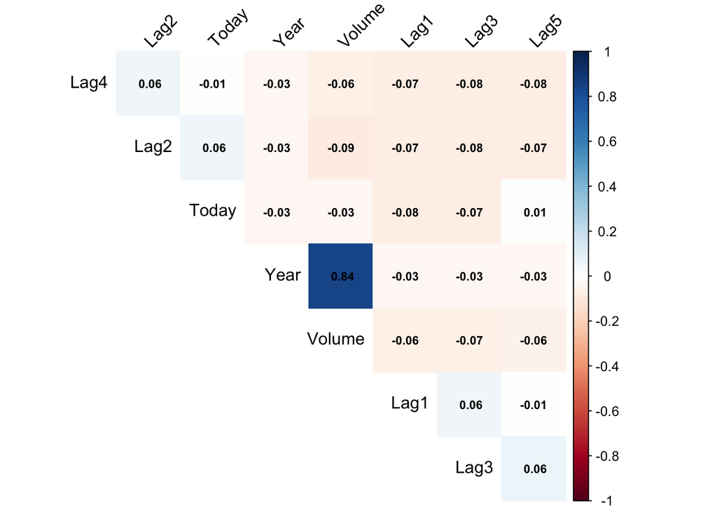

   ```r
   corr_matrix <- cor(Weekly[, -9])
   corrplot(corr_matrix, method = "color",
            type = "upper",
            order = "hclust",
            diag = FALSE,
            tl.col = "black", tl.srt = 45, # Text color and rotation
            addCoef.col = "black", # Add correlation coefficients
            number.cex = 0.7) # Adjust coefficient size
   ```

2. Use the full data set to perform a logistic regression with `Direction` as the response and the five lag variables plus `Volume` as predictors. Use the summary function to print the results. Do any of the predictors appear to be statistically significant? If so, which ones?

   **Solution** Based on the summary, Lag2 is the only predictor that is statically significant, while all other predictor are not significant.

   ```r
   linear_fit <- glm(
     Direction ~ Lag1 + Lag2 + Lag3 + Lag4 + Lag5 + Volume,
     data = Weekly,
     family = binomial)

   summary(linear_fit)
   ```

   ```
   Call:
   glm(formula = Direction ~ Lag1 + Lag2 + Lag3 + Lag4 + Lag5 +
       Volume, family = binomial, data = Weekly)

   Coefficients:
               Estimate Std. Error z value Pr(>|z|)
   (Intercept)  0.26686    0.08593   3.106   0.0019 **
   Lag1        -0.04127    0.02641  -1.563   0.1181
   Lag2         0.05844    0.02686   2.175   0.0296 *
   Lag3        -0.01606    0.02666  -0.602   0.5469
   Lag4        -0.02779    0.02646  -1.050   0.2937
   Lag5        -0.01447    0.02638  -0.549   0.5833
   Volume      -0.02274    0.03690  -0.616   0.5377
   ---
   Signif. codes:  0 '***' 0.001 '**' 0.01 '*' 0.05 '.' 0.1 ' ' 1

   (Dispersion parameter for binomial family taken to be 1)

       Null deviance: 1496.2  on 1088  degrees of freedom
   Residual deviance: 1486.4  on 1082  degrees of freedom
   AIC: 1500.4

   Number of Fisher Scoring iterations: 4
   ```

3. Compute the confusion matrix and overall fraction of correct predictions. Explain what the confusion matrix is telling you about the types of mistakes made by logistic regression.

   **Solution** We can first get the prediction probability and convert the probability to prediction label.

   ```r
   pred_prob <- predict(linear_fit, type = "response") # get prediction probabilities
   pred_label <- ifelse(pred_prob > 0.5, "Up", "Down") # get prediction label
   table(pred_label, Weekly$Direction)
   ```

   ```
   pred_label Down  Up
         Down   54  48
         Up    430 557
   ```

   The confusion matrix output will follow the below form:

   $$\begin{gather}
   Accuracy =
   \frac{TP+TN}{TP + TN + FP + FN} \\
   = \frac{557 + 54}{557 + 54 + 48 + 430} \\
   = 56.1\%
   \end{gather}$$

   ```r
   train <- Weekly$Year < 2009

   lag2_fit <- glm(
     Direction ~ Lag2,
     data = Weekly[train, ],
     family = binomial
   )

   pred_prob <- predict(lag2_fit, Weekly[!train, ], type = "response")
   pred_label <- ifelse(pred_prob > 0.5, "Up", "Down")
   table(pred_label, Weekly[!train, ]$Direction)
   ```

   ```
   pred_label Down Up
         Down    9  5
         Up     34 56
   ```

   Based on the confusion matrix, we can calculate the accuracy based on the formula:

   $$\begin{gather}
   Accuracy = \frac{TP+TN}{TP + TN + FP + FN} \\
   \frac{9+56}{9 + 56 + 34 + 5} \\
   = 62.5\%
   \end{gather}$$
5. Repeat (d) using LDA.

   **Solution**

   ```r
   lda_fit <- lda(
     Direction ~ Lag2,
     data = Weekly[train, ]
   )

   pred_label <- predict(lda_fit, Weekly[!train, ], type = "response")$class
   table(pred_label, Weekly[!train, ]$Direction)
   ```

   ```
   pred_label Down Up
         Down    9  5
         Up     34 56
   ```

   Based on the confusion matrix, we can calculate the accuracy based on the formula:

   $$\begin{gather}
   Accuracy = \frac{TP+TN}{TP + TN + FP + FN} \\
   \frac{9+56}{9 + 56 + 34 + 5} \\
   = 62.5\%
   \end{gather}$$
6. Repeat (d) using QDA.

   **Solution**

   ```r
   qda_fit <- qda(
     Direction ~ Lag2,
     data = Weekly[train, ]
   )

   pred_label <- predict(qda_fit, Weekly[!train, ], type = "response")$class
   table(pred_label, Weekly[!train, ]$Direction)
   ```

   ```
   pred_label Down Up
         Down    0  0
         Up     43 61
   ```

   Based on the confusion matrix, we can calculate the accuracy based on the formula:

   $$\begin{gather}
   Accuracy = \frac{TP+TN}{TP + TN + FP + FN} \\
   \frac{61 + 0}{61 + 0 + 0 + 43} \\
   = 58.7\%
   \end{gather}$$
7. Repeat (d) using KNN with $K = 1$.

   **Solution**

   ```r
   knn_fit <- knn(
     Weekly[train, "Lag2", drop = FALSE],
     Weekly[!train, "Lag2", drop = FALSE],
     Weekly$Direction[train]
   )
   table(knn_fit, Weekly[!train, ]$Direction)
   ```

   ```
   knn_fit Down Up
      Down   21 30
      Up     22 31
   ```

   Based on the confusion matrix, we can calculate the accuracy based on the formula:

   $$\begin{gather}
   Accuracy = \frac{TP+TN}{TP + TN + FP + FN} \\
   \frac{31 + 21}{31 + 21 + 30 + 22} \\
   = 50\%
   \end{gather}$$
8. Repeat (d) using naive Bayes.

   **Solution**

   ```r
   nb_fit <- naiveBayes(
     Direction ~ Lag2,
     data = Weekly[train, ]
   )

   pred_label <- predict(nb_fit, Weekly[!train, ], type = "class")
   table(pred_label, Weekly[!train, ]$Direction)
   ```

   ```
   pred_label Down Up
         Down    0  0
         Up     43 61
   ```

   Based on the confusion matrix, we can calculate the accuracy based on the formula:

   $$\begin{gather}
   Accuracy = \frac{TP+TN}{TP + TN + FP + FN} \\
   \frac{61 + 0}{61 + 0 + 0 + 43} \\
   = 58.7\%
   \end{gather}$$
9. Which of these methods appears to provide the best results on this data?

   **Solution** Based solely on the accuracy result, logistic regression and LDA achieve accuracy of 62.5%, making them the best performing model to predict the stock market trend.

## 5 Bonus question: ISL Exercise 4.8.13 Part (j) (30pts)

Experiment with different combinations of predictors, including possible transformations and interactions, for each of the methods. Report the variables, method, and associated confusion matrix that appears to provide the best results on the held out data. Note that you should also experiment with values for $K$ in the KNN classifier.

**Solution** We can first test on different variables and combination of variables on logistic regression model (one of the best performing models as tested above).

```r
train <- Weekly$Year < 2009
predictors <- c("Lag1", "Lag2", "Lag3", "Lag4",
                "Lag1 + Lag2", "Lag1 + Lag3", "Lag1 + Lag4",
                "Lag2 + Lag3", "Lag2 + Lag4", "Lag3 + Lag4",
                "Lag1 + Lag2 + Lag3", "Lag1 + Lag2 + Lag4",
                "Lag1 + Lag3 + Lag4", "Lag2 + Lag3 + Lag4",
                "Lag1 + Lag2 + Lag3 + Lag4")

results <- data.frame(Predictors = predictors, Accuracy = NA)

for (i in 1:length(predictors)) {
  formula <- paste("Direction ~", predictors[i])  # Create the formula string
  fit <- glm(as.formula(formula), data = Weekly[train, ], family = binomial) # Fit the model

  # Handle potential errors during model fitting
  if(any(class(fit) == "try-error")) {
    print(paste("Error fitting model with predictors:", predictors[i]))
    next # Skip to the next iteration
  }

  pred_prob <- predict(fit, Weekly[!train, ], type = "response")
  pred_label <- ifelse(pred_prob > 0.5, "Up", "Down")

  # Check for NA values in predictions - important for calculating accuracy
  if(any(is.na(pred_label))){
      print(paste("NA values in prediction with predictors:", predictors[i]))
      next
  }

  conf_matrix <- table(pred_label, Weekly$Direction[!train]) # Confusion matrix
  accuracy <- sum(diag(conf_matrix)) / sum(conf_matrix) # Calculate accuracy

  results$Accuracy[i] <- accuracy
}

results_sorted <- results[order(results$Accuracy, decreasing = TRUE), ]
print(results_sorted)
```

```
                  Predictors  Accuracy
2                       Lag2 0.6250000
8                Lag2 + Lag3 0.6250000
9                Lag2 + Lag4 0.6250000
14        Lag2 + Lag3 + Lag4 0.6153846
12        Lag1 + Lag2 + Lag4 0.6057692
6                Lag1 + Lag3 0.5865385
7                Lag1 + Lag4 0.5865385
15 Lag1 + Lag2 + Lag3 + Lag4 0.5865385
5                Lag1 + Lag2 0.5769231
11        Lag1 + Lag2 + Lag3 0.5769231
13        Lag1 + Lag3 + Lag4 0.5769231
1                       Lag1 0.5673077
3                       Lag3 0.4134615
4                       Lag4 0.4134615
10               Lag3 + Lag4 0.4134615
```

Based on this result, it seems like `Lag2` is our best predictor. In addition, `Lag2 + Lag3` and `Lag2 + Lag4` gives the same performance as `Lag2`. Based on the above experiments, we will perform the following experiments using `Lag2` as our predictor.

We can then tune the hyperparameters of the models that we used for prediction. Specifically, we can tune the k (number of neighbors) in KNN model.

```r
library(class)
library(caret)

# Define the predictor and response variables
train_X <- Weekly[train, "Lag2", drop = FALSE]
test_X <- Weekly[!train, "Lag2", drop = FALSE]
train_Y <- Weekly$Direction[train]
test_Y <- Weekly$Direction[!train]

# Define sequence of k values from 10 to 30
k_values <- seq(10, 30)

# Function to compute accuracy for each k
accuracy_results <- sapply(k_values, function(k) {
  pred <- knn(train_X, test_X, train_Y, k = k)
  mean(pred == test_Y)  # Calculate accuracy
})

# Create a dataframe and sort by accuracy
results_df <- data.frame(k = k_values, accuracy = accuracy_results)
results_df <- results_df[order(-results_df$accuracy), ]  # Sort in descending order

# Display sorted results
print(results_df)
```

```
    k  accuracy
1  10 0.5961538
4  13 0.5961538
8  17 0.5961538
3  12 0.5865385
6  15 0.5865385
11 20 0.5769231
13 22 0.5769231
14 23 0.5673077
5  14 0.5576923
10 19 0.5576923
12 21 0.5576923
20 29 0.5576923
2  11 0.5480769
7  16 0.5480769
9  18 0.5384615
15 24 0.5384615
16 25 0.5384615
17 26 0.5384615
21 30 0.5384615
18 27 0.5192308
19 28 0.5192308
```

## 6 Bonus question: ISL Exercise 4.8.4 (30pts)

When the number of features $p$ is large, there tends to be a deterioration in the performance of KNN and other *local* approaches that perform prediction using only observations that are *near* the test observation for which a prediction must be made. This phenomenon is known as the *curse of dimensionality*, and it ties into the fact that non-parametric approaches often perform poorly when $p$ is large. We will now investigate this curse.

1. Suppose that we have a set of observations, each with measurements on $p = 1$ feature, $X$. We assume that $X$ is uniformly (evenly) distributed on $[0, 1]$. Associated with each observation is a response value. Suppose that we wish to predict a test observation’s response using only observations that are within 10% of the range of $X$ closest to that test observation. For instance, in order to predict the response for a test observation with $X = 0.6$, we will use observations in the range $[0.55, 0.65]$. On average, what fraction of the available observations will we use to make the prediction?

   **Solution** For $X$ in $[0.05, 0.95]$, the interval is $[X - 0.05, X + 0.05]$, which is 10% of range. This accounts for 90% of possible x values.

   And for x in $[0, 0.05]$ and $[0.95, 1]$, the interval is $[0, X + 0.05]$ and $[X - 0.05, 1]$, respectively. The average length is 7.5% of length. This accounts for 10% of possible x values.

   $$\begin{gather}
   Percent\ observation = 0.1\times{0.9} + 0.075\times{0.1} \\
   = 9.75\%
   \end{gather}$$
2. Now suppose that we have a set of observations, each with measurements on $p = 2$ features, $X_1$ and $X_2$. We assume that $(X_1, X_2)$ are uniformly distributed on $[0, 1] \times [0, 1]$. We wish to predict a test observation’s response using only observations that are within 10% of the range of $X_1$ *and* within 10% of the range of $X_2$ closest to that test observation. For instance, in order to predict the response for a test observation with $X_1 = 0.6$ and $X_2 = 0.35$, we will use observations in the range $[0.55, 0.65]$ for $X_1$ and in the range $[0.3, 0.4]$ for $X_2$. On average, what fraction of the available observations will we use to make the prediction?

   **Solution** Applying the results from the above question, for $X_1$ and $X_2$, the average fraction of available observations that we can use is $9.75\%$. Therefore, if the observation need to be in range for both $X_1$ and $X_2$, the average percent of observation will be:

   $$\begin{gather}
   Percent\ observation = 0.0975^2 \\
   = 0.95\%
   \end{gather}$$
3. Now suppose that we have a set of observations on $p = 100$ features. Again the observations are uniformly distributed on each feature, and again each feature ranges in value from 0 to 1. We wish to predict a test observation’s response using observations within the 10% of each feature’s range that is closest to that test observation. What fraction of the available observations will we use to make the prediction?

   **Solution** Applying the same principal as above questions, when we have $p = 100$ features, the average percent of observations will be:

   $$\begin{gather}
   Percent\ observation = 0.0975^{100} \\
   = 7.95\times{10^{-100}}\%
   \end{gather}$$

   The percent will be very small and for practical purposes, it would be considered zero.
4. Using your answers to parts (a)–(c), argue that a drawback of KNN when $p$ is large is that there are very few training observations “near” any given test observation.

   **Solution** From what we calculated above, as the number of dimensions $p$ increase, the percent observations will quickly reaches 0. Therefore, the more features that we have, the fewer training observation will be “near” any given test observation.
5. Now suppose that we wish to make a prediction for a test observation by creating a $p$-dimensional hypercube centered around the test observation that contains, on average, 10% of the training observations. For $p = 1,2,$ and $100$, what is the length of each side of the hypercube? Comment on your answer.

   *Note: A hypercube is a generalization of a cube to an arbitrary number of* *dimensions. When* $p = 1$, a hypercube is simply a line segment, when $p = 2$ *it is a square, and when* $p = 100$ it is a 100-dimensional cube.

   **Solution** If the data is uniformly distributed in the unit $p$-dimensional space $[0,1]^p$, the fraction of the total volume occupied by the hypercube is given by:

   $$\begin{align}
   l^p = 0.1 \\
   l = 0.1^{\frac{1}{p}}
   \end{align}$$

   For $p = 1$,

   $$\begin{align}
   l = 0.1^{\frac{1}{1}} = 0.1
   \end{align}$$

   For $p = 2$,

   $$\begin{align}
   l = 0.1^{\frac{1}{2}} = \sqrt{0.1} \approx 0.316
   \end{align}$$

   For $p = 100$,

   $$\begin{align}
   l = 0.1^{\frac{1}{100}} \approx 0.977
   \end{align}$$

   As $p$ increases, $l$ gets closer to 1. This means that in high-dimensional spaces, we must take almost the entire space (nearly the full unit cube) to capture 10% of the training observations. This illustrates the curse of dimensionality—in high dimensions, data points become extremely sparse, making methods like KNN less effective because even large neighborhoods may still contain few relevant points.